# Motor Trend - A study of factors impacting MPG

Asif M Adnan

September 4, 2016

# Executive Summary

In this article we will study “mtcars” data set and find miles per galon (MPG) dependency based on some other parameters. The given data set has `32` samples, and each of the samples have the follwing attributes, `mpg, cyl, disp, hp, drat, wt, qsec, vs, am, gear, carb`. The purpose of this article will be focused around,

- Is an automatic or manual transmission better for MPG?
- Quantify the MPG difference between automatic and manual transmissions?

In order to generate our report, we will go through the following steps one by one,

- Process and Explore target data set.
- Select a good model that can explain the relationship of MPG with the other factors, compared to some counterpart models (Selection and Comparison).
- Conclusion.

# Data Process and Explore

## Process

For this analysis, we need to load the following libraries,

```r
library(ggplot2)
```

Before exploring and analyzing the data set, we need to load and process mtcars.

```r
data("mtcars")
```

Dimesion of the data set,

```r
dim(mtcars)
```

```
## [1] 32 11
```

Attributes of the samples,

```r
names(mtcars)
```

```
##  [1] "mpg"  "cyl"  "disp" "hp"   "drat" "wt"   "qsec" "vs"   "am"   "gear"
## [11] "carb"
```

Some samples

```r
rbind(head(mtcars,3),tail(mtcars,3))
```

```
##                mpg cyl disp  hp drat    wt  qsec vs am gear carb
## Mazda RX4     21.0   6  160 110 3.90 2.620 16.46  0  1    4    4
## Mazda RX4 Wag 21.0   6  160 110 3.90 2.875 17.02  0  1    4    4
## Datsun 710    22.8   4  108  93 3.85 2.320 18.61  1  1    4    1
## Ferrari Dino  19.7   6  145 175 3.62 2.770 15.50  0  1    5    6
## Maserati Bora 15.0   8  301 335 3.54 3.570 14.60  0  1    5    8
## Volvo 142E    21.4   4  121 109 4.11 2.780 18.60  1  1    4    2
```

There are some attributes, which were used as factors (cyl, am, etc.). We need to convert the raw dataset into a format which will help us analyzing the data.

```r
mtcarsModified <- mtcars
mtcarsModified$am <- as.factor(mtcarsModified$am)
levels(mtcarsModified$am) <- c("automatic", "manual")
mtcarsModified$cyl <- as.factor(mtcarsModified$cyl)
mtcarsModified$gear <- as.factor(mtcarsModified$gear)
mtcarsModified$vs <- as.factor(mtcarsModified$vs)
levels(mtcarsModified$vs) <- c("V","S")
```

## Explore

If we draw a box of the data based on the two variables we are interested (MPG vs Transmission), we’ll get the following diagram,

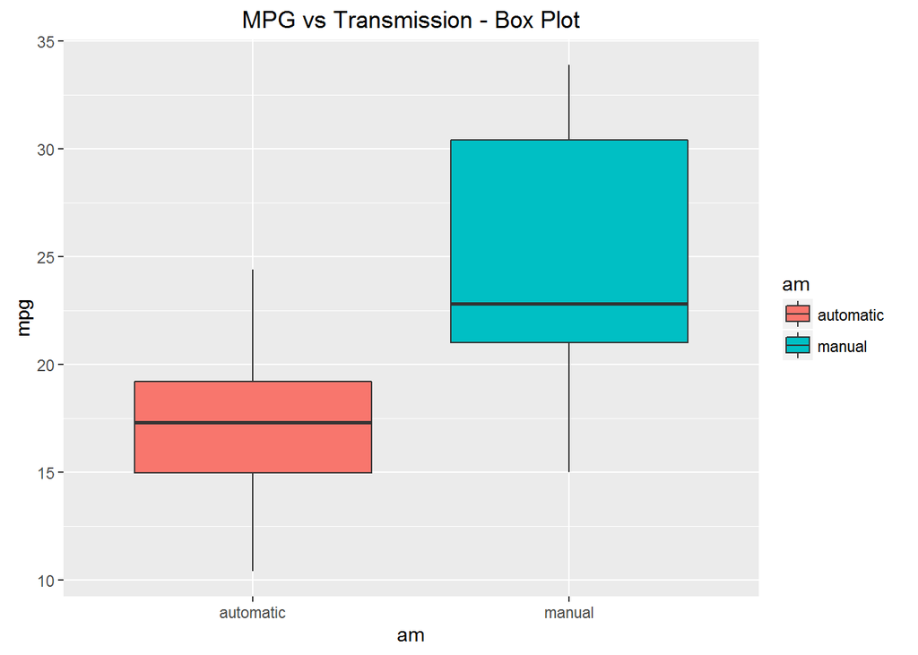

```r
mgpVStransmission <- ggplot(mtcarsModified, aes(am, mpg))+
                    geom_boxplot(aes(fill = am))+
                    labs(title = "MPG vs Transmission - Box Plot")

mgpVStransmission
```

The above graph is showing that, MPG for automatic and manual transmissions are significantly different. We can verify that from the following t-test.

```r
mpgVStransmissionTest <- t.test(mtcarsModified$mpg~mtcarsModified$am)
mpgVStransmissionTest$p.value
```

```
## [1] 0.001373638
```

```r
mpgVStransmissionTest$estimate
```

```
## mean in group automatic    mean in group manual
##                17.14737                24.39231
```

The p-value is siggesting that, automatic and manual transmission data are from two different populations. And the estimated means are quite similar to the box plot we drew.Even though these test suggest that automatic and manusal transmission cars have significantly different MPGs, in order to make sure that there are no biases in the data, we need to farther investigate.

## Correlations

Lets find out the correlations of the attributes with MPG,

```r
correlations <- cor(mtcars$mpg, mtcars)
correlations <- correlations[,order(-abs(correlations[1,]))]
correlations
```

```
##        mpg         wt        cyl       disp         hp       drat
##  1.0000000 -0.8676594 -0.8521620 -0.8475514 -0.7761684  0.6811719
##         vs         am       carb       gear       qsec
##  0.6640389  0.5998324 -0.5509251  0.4802848  0.4186840
```

# Model Selection

We will use linear model to predict the outcome of MPG. At first, we will use only ‘am’ as the predictor. For the second model, we will use all the other variables. As for selecting the best model, we wil use R’s step() function to decide the best model based on the model having all the variables.

## Basic model having ‘am’ as the predictor

We will use ‘am’ attribute as the predictor to decide MPG outcome.

```r
fitAM <- lm(mpg~am, data = mtcarsModified)
#summary(fitAM)$coef
```

## All the attributes as the predictor

In this model, we will use all the available attributes as the predictor.

```r
fitAll <- lm(mpg~., data = mtcarsModified)
#summary(fitAll)$coef
```

## Selecting the best model

We will use R’s step() function in order to select a comparatively good fit.

```r
fitBetter <- step(fitAll, direction = "both", trace = FALSE)
#summary(fitBetter)$coef
```